# Module 93

#### Contrast SVE:

Signed variance explained (SVE) provides an indication of how similar a set of fold changes are to a gene module’s weight vector. An SVE value of 0.3, for example, indicates that 30% of the variance explained by the entire module set is accounted for by the module in question. Shown here are the SVE values for this module across a compendium of fold changes (contrasts). Extreme SVE values (e.g., > 0.05) indicate that those contrasts specifically induce (orange dots) or specifically repress (blue dots) this module. Examining the experimental conditions being compared in such contrasts (see tables below the figure) may provide insight into the gene module’s function.

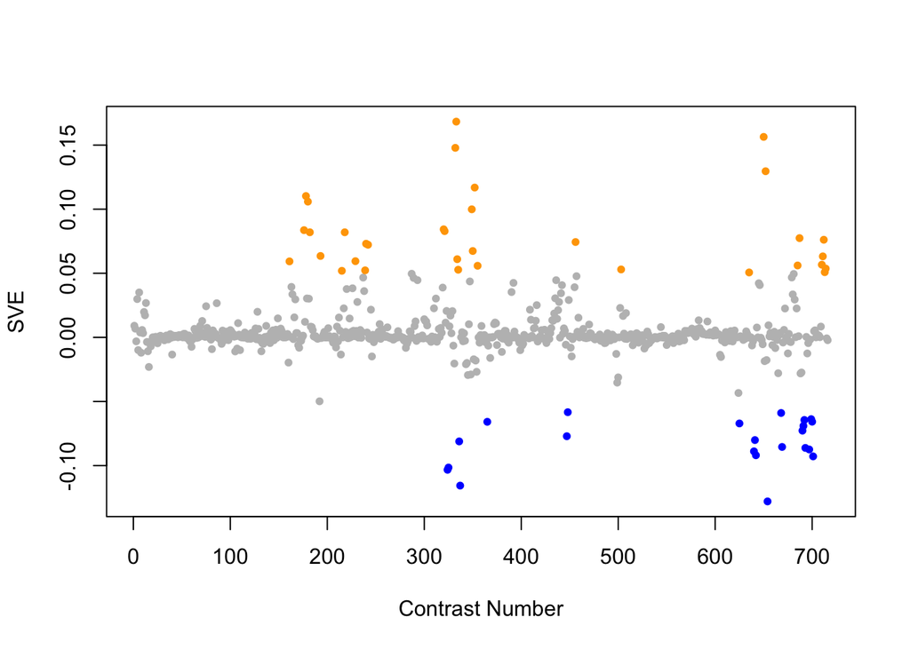

Positive SVE Contrasts:

|  | Contrast.Num | SVE | GEO.GSE | Cond.1 | Cond.2 | Mutation |
| --- | --- | --- | --- | --- | --- | --- |
| GSE38997.s3t2.vs.s1t2 | 333 | 0.17 | GSE38997 | experiment 4 UVC- and EtBr-exposed samples at 24 h 4eu24 | experiment 4 control samples at 24 h 4c24 |  |
| GSE16405.s3t1.vs.s1t1 | 650 | 0.16 | GSE16405 | nth-1;xpa-1_1 | N2_1 | nth-1;xpa-1 |
| GSE38997.s2t2.vs.s1t2 | 332 | 0.15 | GSE38997 | experiment 4 EtBr-exposed samples at 24 h 4e24 | experiment 4 control samples at 24 h 4c24 |  |
| GSE16405.s3t1.vs.s2t1 | 652 | 0.13 | GSE16405 | nth-1;xpa-1_1 | nth-1_1 | xpa-1 |
| GSE38997.s3t2.vs.s3t1 | 352 | 0.12 | GSE38997 | experiment 4 UVC- and EtBr-exposed samples at 24 h 4eu24 | experiment 4 UVC- and EtBr-exposed samples at 3 h 4eu3 |  |
| GSE47778.s2t2.vs.s2t1 | 178 | 0.11 | GSE47778 | daf-2; starvation; replicate 1 | daf-2; replicate 1 |  |
| GSE47778.s4t2.vs.s4t1 | 180 | 0.11 | GSE47778 | daf-2;daf-16; starvation; replicate 1 | daf-2;daf-16; replicate 1 |  |
| GSE38997.s2t2.vs.s2t1 | 349 | 0.10 | GSE38997 | experiment 4 EtBr-exposed samples at 24 h 4e24 | experiment 4 EtBr-exposed samples at 3 h 4e3 |  |
| GSE38997.s2t3.vs.s1t3 | 320 | 0.08 | GSE38997 | experiment 1 EtBr-exposed samples at 48 h 1e48 | experiment 1 control samples at 48 h 1c48 |  |
| GSE47778.s3t2.vs.s3t1 | 176 | 0.08 | GSE47778 | daf-16; starvation; replicate 1 | daf-16; replicate 1 |  |
| GSE38997.s3t3.vs.s1t3 | 321 | 0.08 | GSE38997 | experiment 1 UVC- and EtBr-exposed samples at 48 h 1eu48 | experiment 1 control samples at 48 h 1c48 |  |
| GSE47778.s1t2.vs.s1t1 | 182 | 0.08 | GSE47778 | N2; starvation; replicate 1 | N2; replicate 1 |  |
| GSE42592A.s3t3.vs.s0t3 | 218 | 0.08 | GSE42592 | acrylamide_high_expose-8h_rep1 | acrylamide_control_expose-8h_rep1 |  |
| GSE12298C.s2t1.vs.s0t1 | 687 | 0.08 | GSE12298 | mefloquine_mid_dose-rep1 | mefloquine_control-rep1 |  |
| GSE11055.s2t8.vs.s2t2 | 712 | 0.08 | GSE11055 | L1 larvae 24 hr after hatching in the absence of food | L1 larvae 0 hr after hatching in the absence of food |  |
| GSE24847.s1t2.vs.s1t1 | 456 | 0.07 | GSE24847 | young adult_24hr MWCNT exposure_rep1 | young adult_0h MWCNT exposure_rep1 |  |
| GSE42592C.s3t3.vs.s0t3 | 240 | 0.07 | GSE42592 | mercury_high_expose-8h_rep1 | mercury_control_expose-8h_rep1 |  |
| GSE42592C.s2t3.vs.s0t3 | 242 | 0.07 | GSE42592 | mercury_mid_expose-8h_rep1 | mercury_control_expose-8h_rep1 |  |
| GSE38997.s3t3.vs.s3t1 | 350 | 0.07 | GSE38997 | experiment 1 UVC- and EtBr-exposed samples at 48 h 1eu48 | experiment 4 UVC- and EtBr-exposed samples at 3 h 4eu3 |  |
| GSE45292.s1t1.vs.s0t1 | 193 | 0.06 | GSE45292 | N2 Rifampicin, Biological rep1 | N2 DMSO, Biological rep1 |  |
| GSE11055.s2t7.vs.s2t2 | 711 | 0.06 | GSE11055 | L1 larvae 15 hr after hatching in the absence of food | L1 larvae 0 hr after hatching in the absence of food |  |
| GSE38997.s4t2.vs.s1t2 | 334 | 0.06 | GSE38997 | experiment 4 UVC-exposed samples at 24 h 4u24 | experiment 4 control samples at 24 h 4c24 |  |
| GSE42592B.s3t3.vs.s0t3 | 229 | 0.06 | GSE42592 | cadmium_high_expose-8h_rep1 | cadmium_control_expose-8h_rep1 |  |
| GSE47778.s4t2.vs.s3t2 | 161 | 0.06 | GSE47778 | daf-2;daf-16; starvation; replicate 1 | daf-16; starvation; replicate 1 | daf-2;daf-16 vs. daf-16 |
| GSE11055.s2t6.vs.s2t2 | 710 | 0.06 | GSE11055 | L1 larvae 12 hr after hatching in the absence of food | L1 larvae 0 hr after hatching in the absence of food |  |
| GSE12298C.s3t1.vs.s0t1 | 685 | 0.06 | GSE12298 | mefloquine_high_dose-rep1 | mefloquine_control-rep1 |  |
| GSE38997.s4t2.vs.s4t1 | 355 | 0.06 | GSE38997 | experiment 4 UVC-exposed samples at 24 h 4u24 | experiment 4 UVC-exposed samples at 3 h 4u3 |  |
| GSE11055.s2t5.vs.s2t2 | 714 | 0.05 | GSE11055 | L1 larvae 6 hr after hatching in the absence of food | L1 larvae 0 hr after hatching in the absence of food |  |
| GSE22660.s1t2.vs.s0t2 | 503 | 0.05 | GSE22660 | 1ug/ml ivermectin exposure, biological rep 1 | 1ug/ml DMSO control, biological rep 1 |  |
| GSE38997.s3t2.vs.s2t2 | 335 | 0.05 | GSE38997 | experiment 4 UVC- and EtBr-exposed samples at 24 h 4eu24 | experiment 4 EtBr-exposed samples at 24 h 4e24 |  |
| GSE42592C.s2t2.vs.s0t2 | 239 | 0.05 | GSE42592 | mercury_mid_expose-4h_rep1 | mercury_control_expose-4h_rep1 |  |
| GSE42592A.s3t2.vs.s0t2 | 215 | 0.05 | GSE42592 | acrylamide_high_expose-4h_rep1 | acrylamide_control_expose-4h_rep1 |  |
| GSE11055.s2t4.vs.s2t2 | 713 | 0.05 | GSE11055 | L1 larvae 3 hr after hatching in the absence of food | L1 larvae 0 hr after hatching in the absence of food |  |
| GSE18157.s1t1.vs.s0t1 | 635 | 0.05 | GSE18157 | Caenorhabditis elegans in biotin deficiency 1 | Caenorhabditis elegans grown with sufficient Biotin 1 |  |

Negative SVE Contrasts:

|  | Contrast.Num | SVE | GEO.GSE | Cond.1 | Cond.2 | Mutation |
| --- | --- | --- | --- | --- | --- | --- |
| GSE16405.s4t1.vs.s3t1 | 654 | -0.13 | GSE16405 | xpa-1_1 | nth-1;xpa-1_1 | nth-1 |
| GSE38997.s4t2.vs.s3t2 | 337 | -0.12 | GSE38997 | experiment 4 UVC-exposed samples at 24 h 4u24 | experiment 4 UVC- and EtBr-exposed samples at 24 h 4eu24 |  |
| GSE38997.s4t3.vs.s2t3 | 324 | -0.10 | GSE38997 | experiment 1 UVC-exposed samples at 48 h 1u48 | experiment 1 EtBr-exposed samples at 48 h 1e48 |  |
| GSE38997.s4t3.vs.s3t3 | 325 | -0.10 | GSE38997 | experiment 1 UVC-exposed samples at 48 h 1u48 | experiment 1 UVC- and EtBr-exposed samples at 48 h 1eu48 |  |
| GSE11055.s1t5.vs.s2t5 | 701 | -0.09 | GSE11055 | L1 larvae 6 hr after hatching in the presence of food | L1 larvae 6 hr after hatching in the absence of food |  |
| GSE18132.s0t2.vs.s0t1 | 642 | -0.09 | GSE18132 | WT Fed L4, biological rep1 | WT Starved L1, biological rep1 |  |
| GSE18132.s2t2.vs.s2t1 | 640 | -0.09 | GSE18132 | Oga Fed L4, biological replicate 1 | Oga starved L1, biological replicate 1 |  |
| GSE11055.s1t8.vs.s2t8 | 697 | -0.09 | GSE11055 | L2 larvae 24 hr after hatching in the presence of food | L1 larvae 24 hr after hatching in the absence of food |  |
| GSE11055.s1t7.vs.s2t7 | 693 | -0.09 | GSE11055 | L1-L2 larvae 15 hr after hatching in the presence of food | L1 larvae 15 hr after hatching in the absence of food |  |
| GSE15016.s3t1.vs.s0t1 | 669 | -0.09 | GSE15016 | young adult_24hr DEHP exposure_rep1 | young adult_not exposured_rep1 |  |
| GSE38997.s4t2.vs.s2t2 | 336 | -0.08 | GSE38997 | experiment 4 UVC-exposed samples at 24 h 4u24 | experiment 4 EtBr-exposed samples at 24 h 4e24 |  |
| GSE18132.s1t2.vs.s1t1 | 641 | -0.08 | GSE18132 | Ogt Fed L4, biological replicate 1 | Ogt starved L1, biological replicate 1 |  |
| GSE27401.s1t1.vs.s3t1 | 447 | -0.08 | GSE27401 | Heat Killed E coli #1 | C. albicans alive #1 |  |
| GSE11055.s1t6.vs.s2t6 | 690 | -0.07 | GSE11055 | L1 larvae 12 hr after hatching in the presence of food | L1 larvae 12 hr after hatching in the absence of food |  |
| GSE11055.s4t7.vs.s2t7 | 691 | -0.07 | GSE11055 | L1 larvae fed for 12 hr after hatching and then starved for 3 hr | L1 larvae 15 hr after hatching in the absence of food |  |
| GSE19972.s2t1.vs.s0t1 | 625 | -0.07 | GSE19972 | transgenic myo-4::his-SUMO-1 JS63_1 | control wild type N2_1 |  |
| GSE36358.s3t1.vs.s0t1 | 365 | -0.07 | GSE36358 | Hyper Gravity | Ground Control (Tsukuba space center) |  |
| GSE11055.s1t4.vs.s3t4 | 700 | -0.07 | GSE11055 | L1 larvae 3 hr after hatching in the presence of food | L1 larvae 3 hr after hatching in the absence of food in the alternative starvation buffer M9 |  |
| GSE11055.s5t7.vs.s2t7 | 692 | -0.06 | GSE11055 | L1 larvae starved for 12 hr after hatching and then fed for 3 hr | L1 larvae 15 hr after hatching in the absence of food |  |
| GSE11055.s1t4.vs.s2t4 | 699 | -0.06 | GSE11055 | L1 larvae 3 hr after hatching in the presence of food | L1 larvae 3 hr after hatching in the absence of food |  |
| GSE15016.s4t1.vs.s0t1 | 668 | -0.06 | GSE15016 | young adult_24hr BPA exposure_rep1 | young adult_not exposured_rep1 |  |
| GSE27401.s1t1.vs.s2t1 | 448 | -0.06 | GSE27401 | Heat Killed E coli #1 | Heat Killed C. albicans #1 |  |

$~$

#### Contrast SVE, Up-Regulated Genes Only:

Calculating SVE for up-regulated and down-regulated genes separately may be more informative in many cases than projecting the up- and down- gene sets together. This is due to the fact that the weight distribution of many modules is highly skewed, indicating that only one of the hemi-modules may be biologically meaningful (i.e., a set of genes are strongly correlated by only a few genes (or none) are strongly anti-correlated to that set.)

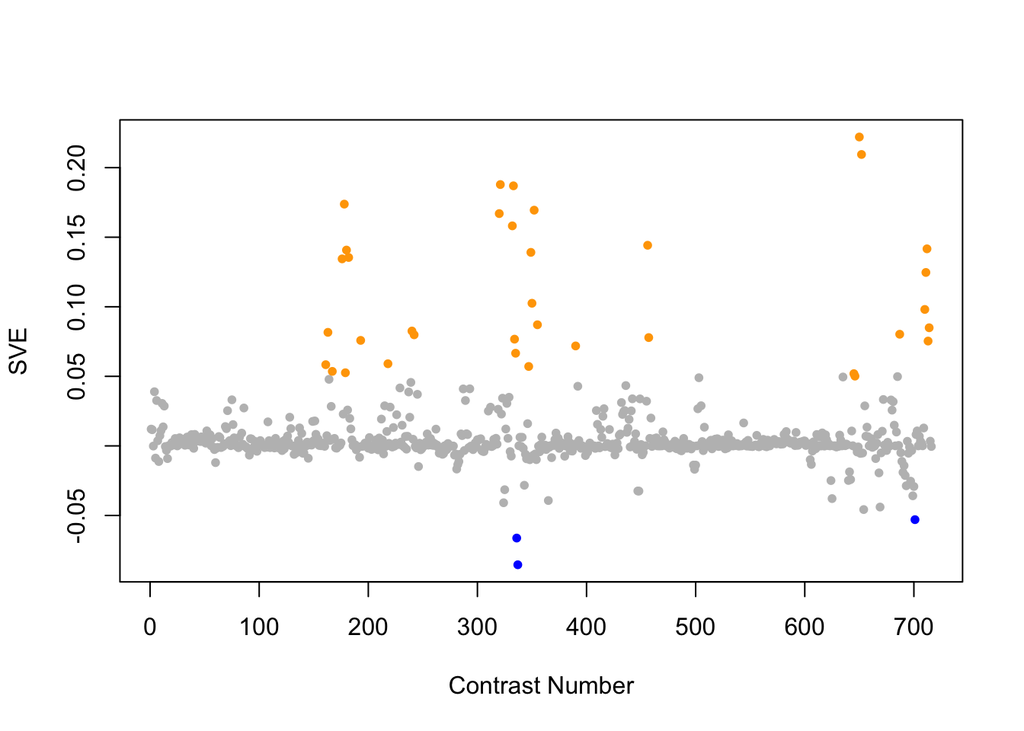

Positive SVE Contrasts:

|  | Contrast.Num | SVE | GEO.GSE | Cond.1 | Cond.2 | Mutation |
| --- | --- | --- | --- | --- | --- | --- |
| GSE16405.s3t1.vs.s1t1 | 650 | 0.22 | GSE16405 | nth-1;xpa-1_1 | N2_1 | nth-1;xpa-1 |
| GSE16405.s3t1.vs.s2t1 | 652 | 0.21 | GSE16405 | nth-1;xpa-1_1 | nth-1_1 | xpa-1 |
| GSE38997.s3t3.vs.s1t3 | 321 | 0.19 | GSE38997 | experiment 1 UVC- and EtBr-exposed samples at 48 h 1eu48 | experiment 1 control samples at 48 h 1c48 |  |
| GSE38997.s3t2.vs.s1t2 | 333 | 0.19 | GSE38997 | experiment 4 UVC- and EtBr-exposed samples at 24 h 4eu24 | experiment 4 control samples at 24 h 4c24 |  |
| GSE47778.s2t2.vs.s2t1 | 178 | 0.17 | GSE47778 | daf-2; starvation; replicate 1 | daf-2; replicate 1 |  |
| GSE38997.s3t2.vs.s3t1 | 352 | 0.17 | GSE38997 | experiment 4 UVC- and EtBr-exposed samples at 24 h 4eu24 | experiment 4 UVC- and EtBr-exposed samples at 3 h 4eu3 |  |
| GSE38997.s2t3.vs.s1t3 | 320 | 0.17 | GSE38997 | experiment 1 EtBr-exposed samples at 48 h 1e48 | experiment 1 control samples at 48 h 1c48 |  |
| GSE38997.s2t2.vs.s1t2 | 332 | 0.16 | GSE38997 | experiment 4 EtBr-exposed samples at 24 h 4e24 | experiment 4 control samples at 24 h 4c24 |  |
| GSE24847.s1t2.vs.s1t1 | 456 | 0.14 | GSE24847 | young adult_24hr MWCNT exposure_rep1 | young adult_0h MWCNT exposure_rep1 |  |
| GSE11055.s2t8.vs.s2t2 | 712 | 0.14 | GSE11055 | L1 larvae 24 hr after hatching in the absence of food | L1 larvae 0 hr after hatching in the absence of food |  |
| GSE47778.s4t2.vs.s4t1 | 180 | 0.14 | GSE47778 | daf-2;daf-16; starvation; replicate 1 | daf-2;daf-16; replicate 1 |  |
| GSE38997.s2t2.vs.s2t1 | 349 | 0.14 | GSE38997 | experiment 4 EtBr-exposed samples at 24 h 4e24 | experiment 4 EtBr-exposed samples at 3 h 4e3 |  |
| GSE47778.s1t2.vs.s1t1 | 182 | 0.14 | GSE47778 | N2; starvation; replicate 1 | N2; replicate 1 |  |
| GSE47778.s3t2.vs.s3t1 | 176 | 0.13 | GSE47778 | daf-16; starvation; replicate 1 | daf-16; replicate 1 |  |
| GSE11055.s2t7.vs.s2t2 | 711 | 0.12 | GSE11055 | L1 larvae 15 hr after hatching in the absence of food | L1 larvae 0 hr after hatching in the absence of food |  |
| GSE38997.s3t3.vs.s3t1 | 350 | 0.10 | GSE38997 | experiment 1 UVC- and EtBr-exposed samples at 48 h 1eu48 | experiment 4 UVC- and EtBr-exposed samples at 3 h 4eu3 |  |
| GSE11055.s2t6.vs.s2t2 | 710 | 0.10 | GSE11055 | L1 larvae 12 hr after hatching in the absence of food | L1 larvae 0 hr after hatching in the absence of food |  |
| GSE38997.s4t2.vs.s4t1 | 355 | 0.09 | GSE38997 | experiment 4 UVC-exposed samples at 24 h 4u24 | experiment 4 UVC-exposed samples at 3 h 4u3 |  |
| GSE11055.s2t5.vs.s2t2 | 714 | 0.08 | GSE11055 | L1 larvae 6 hr after hatching in the absence of food | L1 larvae 0 hr after hatching in the absence of food |  |
| GSE42592C.s3t3.vs.s0t3 | 240 | 0.08 | GSE42592 | mercury_high_expose-8h_rep1 | mercury_control_expose-8h_rep1 |  |
| GSE47778.s4t2.vs.s2t2 | 163 | 0.08 | GSE47778 | daf-2;daf-16; starvation; replicate 1 | daf-2; starvation; replicate 1 | daf-2;daf-16 vs. daf-2 |
| GSE12298C.s2t1.vs.s0t1 | 687 | 0.08 | GSE12298 | mefloquine_mid_dose-rep1 | mefloquine_control-rep1 |  |
| GSE42592C.s2t3.vs.s0t3 | 242 | 0.08 | GSE42592 | mercury_mid_expose-8h_rep1 | mercury_control_expose-8h_rep1 |  |
| GSE24847.s1t3.vs.s1t1 | 457 | 0.08 | GSE24847 | young adult_4hr MWCNT exposure_rep1 | young adult_0h MWCNT exposure_rep1 |  |
| GSE38997.s4t2.vs.s1t2 | 334 | 0.08 | GSE38997 | experiment 4 UVC-exposed samples at 24 h 4u24 | experiment 4 control samples at 24 h 4c24 |  |
| GSE45292.s1t1.vs.s0t1 | 193 | 0.08 | GSE45292 | N2 Rifampicin, Biological rep1 | N2 DMSO, Biological rep1 |  |
| GSE11055.s2t4.vs.s2t2 | 713 | 0.08 | GSE11055 | L1 larvae 3 hr after hatching in the absence of food | L1 larvae 0 hr after hatching in the absence of food |  |
| GSE32521.s1t1.vs.s0t1 | 390 | 0.07 | GSE32521 | Au-NP Replicate1 | Control Replicate1 |  |
| GSE38997.s3t2.vs.s2t2 | 335 | 0.07 | GSE38997 | experiment 4 UVC- and EtBr-exposed samples at 24 h 4eu24 | experiment 4 EtBr-exposed samples at 24 h 4e24 |  |
| GSE42592A.s3t3.vs.s0t3 | 218 | 0.06 | GSE42592 | acrylamide_high_expose-8h_rep1 | acrylamide_control_expose-8h_rep1 |  |
| GSE47778.s4t2.vs.s3t2 | 161 | 0.06 | GSE47778 | daf-2;daf-16; starvation; replicate 1 | daf-16; starvation; replicate 1 | daf-2;daf-16 vs. daf-16 |
| GSE38997.s2t3.vs.s2t1 | 347 | 0.06 | GSE38997 | experiment 1 EtBr-exposed samples at 48 h 1e48 | experiment 4 EtBr-exposed samples at 3 h 4e3 |  |
| GSE47778.s4t3.vs.s3t3 | 167 | 0.05 | GSE47778 | daf-2;daf-16; UV; replicate 1 | daf-16; UV; replicate 1 | daf-2;daf-16 vs. daf-16 |
| GSE47778.s2t3.vs.s2t1 | 179 | 0.05 | GSE47778 | daf-2; UV; replicate 1 | daf-2; replicate 1 |  |
| GSE16915.s2t1.vs.s3t1 | 645 | 0.05 | GSE16915 | positive control (heat shock) | bio-electrosprayed sample |  |
| GSE16915.s2t1.vs.s1t1 | 646 | 0.05 | GSE16915 | positive control (heat shock) | control sample |  |

Negative SVE Contrasts:

|  | Contrast.Num | SVE | GEO.GSE | Cond.1 | Cond.2 | Mutation |
| --- | --- | --- | --- | --- | --- | --- |
| GSE38997.s4t2.vs.s3t2 | 337 | -0.09 | GSE38997 | experiment 4 UVC-exposed samples at 24 h 4u24 | experiment 4 UVC- and EtBr-exposed samples at 24 h 4eu24 |  |
| GSE38997.s4t2.vs.s2t2 | 336 | -0.07 | GSE38997 | experiment 4 UVC-exposed samples at 24 h 4u24 | experiment 4 EtBr-exposed samples at 24 h 4e24 |  |
| GSE11055.s1t5.vs.s2t5 | 701 | -0.05 | GSE11055 | L1 larvae 6 hr after hatching in the presence of food | L1 larvae 6 hr after hatching in the absence of food |  |
| GSE16405.s4t1.vs.s3t1 | 654 | -0.05 | GSE16405 | xpa-1_1 | nth-1;xpa-1_1 | nth-1 |
| GSE15016.s3t1.vs.s0t1 | 669 | -0.04 | GSE15016 | young adult_24hr DEHP exposure_rep1 | young adult_not exposured_rep1 |  |

$~$

#### Contrast SVE, Down-Regulated Genes Only:

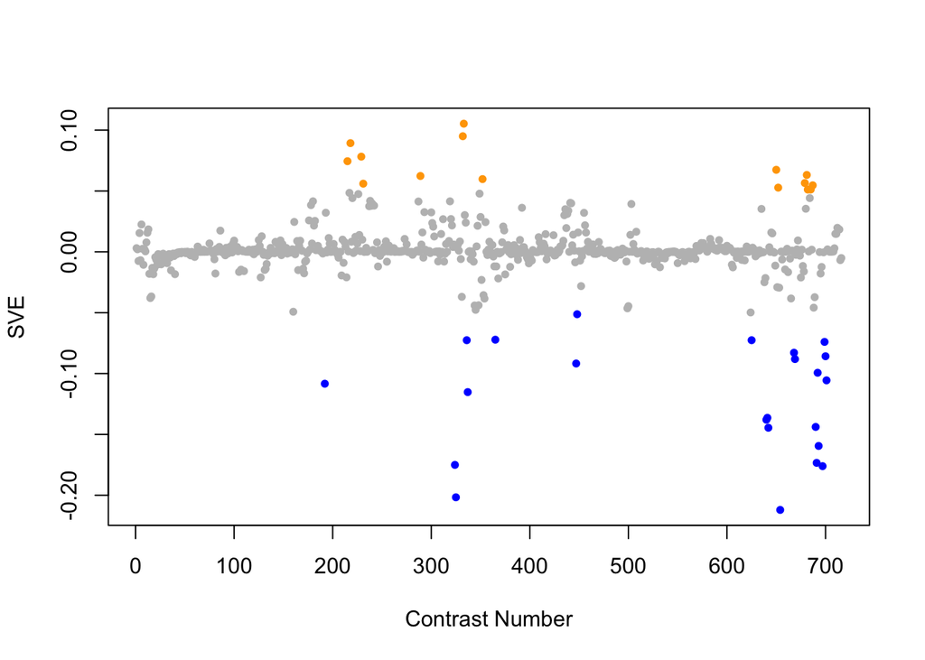

Positive SVE Contrasts:

|  | Contrast.Num | SVE | GEO.GSE | Cond.1 | Cond.2 | Mutation |
| --- | --- | --- | --- | --- | --- | --- |
| GSE38997.s3t2.vs.s1t2 | 333 | 0.11 | GSE38997 | experiment 4 UVC- and EtBr-exposed samples at 24 h 4eu24 | experiment 4 control samples at 24 h 4c24 |  |
| GSE38997.s2t2.vs.s1t2 | 332 | 0.10 | GSE38997 | experiment 4 EtBr-exposed samples at 24 h 4e24 | experiment 4 control samples at 24 h 4c24 |  |
| GSE42592A.s3t3.vs.s0t3 | 218 | 0.09 | GSE42592 | acrylamide_high_expose-8h_rep1 | acrylamide_control_expose-8h_rep1 |  |
| GSE42592B.s3t3.vs.s0t3 | 229 | 0.08 | GSE42592 | cadmium_high_expose-8h_rep1 | cadmium_control_expose-8h_rep1 |  |
| GSE42592A.s3t2.vs.s0t2 | 215 | 0.07 | GSE42592 | acrylamide_high_expose-4h_rep1 | acrylamide_control_expose-4h_rep1 |  |
| GSE16405.s3t1.vs.s1t1 | 650 | 0.07 | GSE16405 | nth-1;xpa-1_1 | N2_1 | nth-1;xpa-1 |
| GSE12298A.s2t1.vs.s0t1 | 681 | 0.06 | GSE12298 | dichlorvos_mid_dose-rep1 | dichlorvos_control-rep1 |  |
| GSE41366C.s2t5.vs.s0t5 | 289 | 0.06 | GSE41366 | high_DDVP-continuous_expose-26h_harvest-rep1 | control-continuous_expose-20h_harvest-rep1 |  |
| GSE38997.s3t2.vs.s3t1 | 352 | 0.06 | GSE38997 | experiment 4 UVC- and EtBr-exposed samples at 24 h 4eu24 | experiment 4 UVC- and EtBr-exposed samples at 3 h 4eu3 |  |
| GSE12298A.s3t1.vs.s0t1 | 679 | 0.06 | GSE12298 | dichlorvos_high_dose-rep1 | dichlorvos_control-rep1 |  |
| GSE42592B.s2t3.vs.s0t3 | 231 | 0.06 | GSE42592 | cadmium_mid_expose-8h_rep1 | cadmium_control_expose-8h_rep1 |  |
| GSE12298C.s2t1.vs.s0t1 | 687 | 0.05 | GSE12298 | mefloquine_mid_dose-rep1 | mefloquine_control-rep1 |  |
| GSE16405.s3t1.vs.s2t1 | 652 | 0.05 | GSE16405 | nth-1;xpa-1_1 | nth-1_1 | xpa-1 |
| GSE12298C.s3t1.vs.s0t1 | 685 | 0.05 | GSE12298 | mefloquine_high_dose-rep1 | mefloquine_control-rep1 |  |
| GSE12298B.s3t1.vs.s0t1 | 682 | 0.05 | GSE12298 | fenamiphos_high_dose-rep1 | fenamiphos_control-rep1 |  |

Negative SVE Contrasts:

|  | Contrast.Num | SVE | GEO.GSE | Cond.1 | Cond.2 | Mutation |
| --- | --- | --- | --- | --- | --- | --- |
| GSE16405.s4t1.vs.s3t1 | 654 | -0.21 | GSE16405 | xpa-1_1 | nth-1;xpa-1_1 | nth-1 |
| GSE38997.s4t3.vs.s3t3 | 325 | -0.20 | GSE38997 | experiment 1 UVC-exposed samples at 48 h 1u48 | experiment 1 UVC- and EtBr-exposed samples at 48 h 1eu48 |  |
| GSE11055.s1t8.vs.s2t8 | 697 | -0.18 | GSE11055 | L2 larvae 24 hr after hatching in the presence of food | L1 larvae 24 hr after hatching in the absence of food |  |
| GSE38997.s4t3.vs.s2t3 | 324 | -0.18 | GSE38997 | experiment 1 UVC-exposed samples at 48 h 1u48 | experiment 1 EtBr-exposed samples at 48 h 1e48 |  |
| GSE11055.s4t7.vs.s2t7 | 691 | -0.17 | GSE11055 | L1 larvae fed for 12 hr after hatching and then starved for 3 hr | L1 larvae 15 hr after hatching in the absence of food |  |
| GSE11055.s1t7.vs.s2t7 | 693 | -0.16 | GSE11055 | L1-L2 larvae 15 hr after hatching in the presence of food | L1 larvae 15 hr after hatching in the absence of food |  |
| GSE18132.s0t2.vs.s0t1 | 642 | -0.14 | GSE18132 | WT Fed L4, biological rep1 | WT Starved L1, biological rep1 |  |
| GSE11055.s1t6.vs.s2t6 | 690 | -0.14 | GSE11055 | L1 larvae 12 hr after hatching in the presence of food | L1 larvae 12 hr after hatching in the absence of food |  |
| GSE18132.s2t2.vs.s2t1 | 640 | -0.14 | GSE18132 | Oga Fed L4, biological replicate 1 | Oga starved L1, biological replicate 1 |  |
| GSE18132.s1t2.vs.s1t1 | 641 | -0.14 | GSE18132 | Ogt Fed L4, biological replicate 1 | Ogt starved L1, biological replicate 1 |  |
| GSE38997.s4t2.vs.s3t2 | 337 | -0.12 | GSE38997 | experiment 4 UVC-exposed samples at 24 h 4u24 | experiment 4 UVC- and EtBr-exposed samples at 24 h 4eu24 |  |
| GSE45651.s1t1.vs.s0t1 | 192 | -0.11 | GSE45651 | starved L1 lin-35(n745), biological rep1 | starved L1 wild type worm, biological rep1 | lin-35 |
| GSE11055.s1t5.vs.s2t5 | 701 | -0.11 | GSE11055 | L1 larvae 6 hr after hatching in the presence of food | L1 larvae 6 hr after hatching in the absence of food |  |
| GSE11055.s5t7.vs.s2t7 | 692 | -0.10 | GSE11055 | L1 larvae starved for 12 hr after hatching and then fed for 3 hr | L1 larvae 15 hr after hatching in the absence of food |  |
| GSE27401.s1t1.vs.s3t1 | 447 | -0.09 | GSE27401 | Heat Killed E coli #1 | C. albicans alive #1 |  |
| GSE15016.s3t1.vs.s0t1 | 669 | -0.09 | GSE15016 | young adult_24hr DEHP exposure_rep1 | young adult_not exposured_rep1 |  |
| GSE11055.s1t4.vs.s3t4 | 700 | -0.09 | GSE11055 | L1 larvae 3 hr after hatching in the presence of food | L1 larvae 3 hr after hatching in the absence of food in the alternative starvation buffer M9 |  |
| GSE15016.s4t1.vs.s0t1 | 668 | -0.08 | GSE15016 | young adult_24hr BPA exposure_rep1 | young adult_not exposured_rep1 |  |
| GSE11055.s1t4.vs.s2t4 | 699 | -0.07 | GSE11055 | L1 larvae 3 hr after hatching in the presence of food | L1 larvae 3 hr after hatching in the absence of food |  |
| GSE38997.s4t2.vs.s2t2 | 336 | -0.07 | GSE38997 | experiment 4 UVC-exposed samples at 24 h 4u24 | experiment 4 EtBr-exposed samples at 24 h 4e24 |  |
| GSE19972.s2t1.vs.s0t1 | 625 | -0.07 | GSE19972 | transgenic myo-4::his-SUMO-1 JS63_1 | control wild type N2_1 |  |
| GSE36358.s3t1.vs.s0t1 | 365 | -0.07 | GSE36358 | Hyper Gravity | Ground Control (Tsukuba space center) |  |
| GSE27401.s1t1.vs.s2t1 | 448 | -0.05 | GSE27401 | Heat Killed E coli #1 | Heat Killed C. albicans #1 |  |

$~$

$~$

#### GO Term Enrichment:

This analysis tests each hemi-module for enrichment of specific GO terms. Only gene-level annotations (e.g., as would be found on the gene’s page in Wormbase) are tested - the hierarchical structure of the GO ontology is not taken into account.

*Note: At least the top two most enriched terms from each GO domain (BP/MF/CC) are shown, even when not statistically significant.*

##### Enriched GO terms: Hemi-module A

| ID | GO.Term | GO Domain | Raw p-value | Adj p-value |
| --- | --- | --- | --- | --- |
| [GO_0042254](http://amigo.geneontology.org/amigo/term/GO:0042254) | ribosome biogenesis | BP | 2.85e-08 | 1.04e-04 |
| [GO_0042273](http://amigo.geneontology.org/amigo/term/GO:0042273) | ribosomal large subunit biogenesis | BP | 8.24e-06 | 1.03e-02 |
| [GO_0006412](http://amigo.geneontology.org/amigo/term/GO:0006412) | translation | BP | 8.47e-06 | 1.03e-02 |
| [GO_0030490](http://amigo.geneontology.org/amigo/term/GO:0030490) | maturation of SSU-rRNA | BP | 1.78e-05 | 1.62e-02 |
| [GO_0000055](http://amigo.geneontology.org/amigo/term/GO:0000055) | ribosomal large subunit export from nucleus | BP | 5.18e-05 | 3.65e-02 |
| [GO_0006364](http://amigo.geneontology.org/amigo/term/GO:0006364) | rRNA processing | BP | 6.50e-05 | 3.65e-02 |
| [GO_0006418](http://amigo.geneontology.org/amigo/term/GO:0006418) | tRNA aminoacylation for protein translation | BP | 7.71e-05 | 3.65e-02 |
| [GO_0002098](http://amigo.geneontology.org/amigo/term/GO:0002098) | tRNA wobble uridine modification | BP | 8.02e-05 | 3.65e-02 |
| [GO_0042274](http://amigo.geneontology.org/amigo/term/GO:0042274) | ribosomal small subunit biogenesis | BP | 1.02e-04 | 3.73e-02 |
| [GO_0045859](http://amigo.geneontology.org/amigo/term/GO:0045859) | regulation of protein kinase activity | BP | 1.02e-04 | 3.73e-02 |
| [GO_0000462](http://amigo.geneontology.org/amigo/term/GO:0000462) | maturation of SSU-rRNA from tricistronic rRNA transcript (SSU-rRNA, 5.8S rRNA, LSU-rRNA) | BP | 2.32e-04 | 7.68e-02 |
| [GO_0034473](http://amigo.geneontology.org/amigo/term/GO:0034473) | U1 snRNA 3’-end processing | BP | 3.06e-04 | 7.97e-02 |
| [GO_0034476](http://amigo.geneontology.org/amigo/term/GO:0034476) | U5 snRNA 3’-end processing | BP | 3.06e-04 | 7.97e-02 |
| [GO_0071042](http://amigo.geneontology.org/amigo/term/GO:0071042) | nuclear polyadenylation-dependent mRNA catabolic process | BP | 3.06e-04 | 7.97e-02 |
| [GO_0000027](http://amigo.geneontology.org/amigo/term/GO:0000027) | ribosomal large subunit assembly | BP | 4.35e-04 | 9.94e-02 |
| [GO_0008033](http://amigo.geneontology.org/amigo/term/GO:0008033) | tRNA processing | BP | 4.37e-04 | 9.94e-02 |
| [GO_0004812](http://amigo.geneontology.org/amigo/term/GO:0004812) | aminoacyl-tRNA ligase activity | MF | 2.02e-05 | 2.94e-02 |
| [GO_0000166](http://amigo.geneontology.org/amigo/term/GO:0000166) | nucleotide binding | MF | 2.88e-05 | 2.94e-02 |
| [GO_0051082](http://amigo.geneontology.org/amigo/term/GO:0051082) | unfolded protein binding | MF | 9.02e-05 | 6.15e-02 |
| [GO_0005730](http://amigo.geneontology.org/amigo/term/GO:0005730) | nucleolus | CC | 1.41e-23 | 1.31e-20 |
| [GO_0030688](http://amigo.geneontology.org/amigo/term/GO:0030688) | preribosome, small subunit precursor | CC | 1.61e-11 | 7.49e-09 |
| [GO_0030687](http://amigo.geneontology.org/amigo/term/GO:0030687) | preribosome, large subunit precursor | CC | 3.24e-11 | 7.80e-09 |
| [GO_0016021](http://amigo.geneontology.org/amigo/term/GO:0016021) | integral component of membrane | CC | 3.36e-11 | 7.80e-09 |
| [GO_0016020](http://amigo.geneontology.org/amigo/term/GO:0016020) | membrane | CC | 2.42e-09 | 4.48e-07 |
| [GO_0005737](http://amigo.geneontology.org/amigo/term/GO:0005737) | cytoplasm | CC | 2.37e-04 | 3.67e-02 |
| [GO_0005956](http://amigo.geneontology.org/amigo/term/GO:0005956) | protein kinase CK2 complex | CC | 3.06e-04 | 4.06e-02 |

##### Enriched GO terms: Hemi-module B

| ID | GO.Term | GO Domain | Raw p-value | Adj p-value |
| --- | --- | --- | --- | --- |
| [GO_0055114](http://amigo.geneontology.org/amigo/term/GO:0055114) | oxidation-reduction process | BP | 3.08e-09 | 1.12e-05 |
| [GO_0006631](http://amigo.geneontology.org/amigo/term/GO:0006631) | fatty acid metabolic process | BP | 9.43e-06 | 1.72e-02 |
| [GO_0016491](http://amigo.geneontology.org/amigo/term/GO:0016491) | oxidoreductase activity | MF | 4.40e-05 | 8.99e-02 |
| [GO_0047617](http://amigo.geneontology.org/amigo/term/GO:0047617) | acyl-CoA hydrolase activity | MF | 6.11e-04 | 6.24e-01 |
| [GO_0005789](http://amigo.geneontology.org/amigo/term/GO:0005789) | endoplasmic reticulum membrane | CC | 8.29e-04 | 6.86e-01 |
| [GO_0005783](http://amigo.geneontology.org/amigo/term/GO:0005783) | endoplasmic reticulum | CC | 1.48e-03 | 6.86e-01 |

$~$

$~$

#### Tissue Enrichment:

This analysis tests each hemi-module for enrichment of genes associated with anatomy terms. Negative enrichment scores indicate fewer hemi-module genes than expected by random chance were associated with the anatomy term in question.

##### Enriched tissues: Hemi-module A

| ID | Anatomy.Term | Definition | Raw p-value | Adj p-value |
| --- | --- | --- | --- | --- |
| [WBbt_0005813](https://wormbase.org/species/all/anatomy_term/WBbt:0005813) | body wall musculature | Longitudinal bands of muscle cells surrounding animal body, with one band running in each quadrant of the body, regulated contraction and relaxation of these muscles cause locomotion. | 2.25e-05 | 4.92e-02 |
| [WBbt_0003681](https://wormbase.org/species/all/anatomy_term/WBbt:0003681) | pharynx | the feeding organ, a neuro-muscular pump in the head of the animal, used to ingest food, bacteria suspended in liquid, filter them out, grind them up and transport posteriorly into the instestine. | 4.05e-05 | 4.92e-02 |

##### Enriched tissues: Hemi-module B

No significant annotations.

$~$

$~$

#### HOMER promoter motif enrichment:

This analysis tests each hemi-module for enrichment of 108 known *C. elegans* transcription factor binding site motifs (see [108 CE motifs](https://katiepod.github.io//all.worm.motifs.html)) using the HOMER (Hypergeometric Optimization of Motif EnRichment) software (see [PMID:20513432](https://pubmed.ncbi.nlm.nih.gov/20513432)). HOMER was run using default parameters on sequences 1 kb upstream of the transcription start site.

##### Motif enrichment: Hemi-module A

Total target sequences = 259  
Total background sequences = 39282  
* - possible false positive

Rank

Motif

P-value

log P-pvalue

% of Targets

% of Background

STD(Bg STD)

Best Match/Details

Motif File

1

[figure not shown]

1e-12

-2.794e+01

24.32%

9.17%

271.5bp (324.7bp)

sma-4/MA0925.1/Jaspar(0.635)  
[More Information](https://katiepod.github.io/HomerResults/m93_a_hemi_genes.txt.out.1kb/homerResults/motif1.info.html) | [Similar Motifs Found](https://katiepod.github.io/HomerResults/m93_a_hemi_genes.txt.out.1kb/homerResults/motif1.similar.html)

[motif file (matrix)](https://katiepod.github.io/HomerResults/m93_a_hemi_genes.txt.out.1kb/homerResults/motif1.motif)

2 *

[figure not shown]

1e-11

-2.693e+01

6.56%

0.62%

280.8bp (305.0bp)

PL0009.1_hlh-26/Jaspar(0.537)  
[More Information](https://katiepod.github.io/HomerResults/m93_a_hemi_genes.txt.out.1kb/homerResults/motif2.info.html) | [Similar Motifs Found](https://katiepod.github.io/HomerResults/m93_a_hemi_genes.txt.out.1kb/homerResults/motif2.similar.html)

[motif file (matrix)](https://katiepod.github.io/HomerResults/m93_a_hemi_genes.txt.out.1kb/homerResults/motif2.motif)

3 *

[figure not shown]

1e-11

-2.616e+01

11.58%

2.45%

268.3bp (296.7bp)

lin-54/MA1450.1/Jaspar(0.600)  
[More Information](https://katiepod.github.io/HomerResults/m93_a_hemi_genes.txt.out.1kb/homerResults/motif3.info.html) | [Similar Motifs Found](https://katiepod.github.io/HomerResults/m93_a_hemi_genes.txt.out.1kb/homerResults/motif3.similar.html)

[motif file (matrix)](https://katiepod.github.io/HomerResults/m93_a_hemi_genes.txt.out.1kb/homerResults/motif3.motif)

4 *

[figure not shown]

1e-10

-2.463e+01

8.49%

1.35%

302.4bp (365.4bp)

SD0001.1_at_AC_acceptor/Jaspar(0.649)  
[More Information](https://katiepod.github.io/HomerResults/m93_a_hemi_genes.txt.out.1kb/homerResults/motif4.info.html) | [Similar Motifs Found](https://katiepod.github.io/HomerResults/m93_a_hemi_genes.txt.out.1kb/homerResults/motif4.similar.html)

[motif file (matrix)](https://katiepod.github.io/HomerResults/m93_a_hemi_genes.txt.out.1kb/homerResults/motif4.motif)

5 *

[figure not shown]

1e-10

-2.438e+01

5.79%

0.53%

289.3bp (303.8bp)

pha-4/MA0546.1/Jaspar(0.675)  
[More Information](https://katiepod.github.io/HomerResults/m93_a_hemi_genes.txt.out.1kb/homerResults/motif5.info.html) | [Similar Motifs Found](https://katiepod.github.io/HomerResults/m93_a_hemi_genes.txt.out.1kb/homerResults/motif5.similar.html)

[motif file (matrix)](https://katiepod.github.io/HomerResults/m93_a_hemi_genes.txt.out.1kb/homerResults/motif5.motif)

6 *

[figure not shown]

1e-10

-2.394e+01

14.67%

4.22%

254.7bp (345.8bp)

skn-1/MA0547.1/Jaspar(0.760)  
[More Information](https://katiepod.github.io/HomerResults/m93_a_hemi_genes.txt.out.1kb/homerResults/motif6.info.html) | [Similar Motifs Found](https://katiepod.github.io/HomerResults/m93_a_hemi_genes.txt.out.1kb/homerResults/motif6.similar.html)

[motif file (matrix)](https://katiepod.github.io/HomerResults/m93_a_hemi_genes.txt.out.1kb/homerResults/motif6.motif)

7 *

[figure not shown]

1e-10

-2.391e+01

8.49%

1.40%

263.1bp (310.5bp)

lin-54/MA1450.1/Jaspar(0.747)  
[More Information](https://katiepod.github.io/HomerResults/m93_a_hemi_genes.txt.out.1kb/homerResults/motif7.info.html) | [Similar Motifs Found](https://katiepod.github.io/HomerResults/m93_a_hemi_genes.txt.out.1kb/homerResults/motif7.similar.html)

[motif file (matrix)](https://katiepod.github.io/HomerResults/m93_a_hemi_genes.txt.out.1kb/homerResults/motif7.motif)

8 *

[figure not shown]

1e-10

-2.391e+01

4.25%

0.22%

220.1bp (309.2bp)

POL004.1_CCAAT-box/Jaspar(0.586)  
[More Information](https://katiepod.github.io/HomerResults/m93_a_hemi_genes.txt.out.1kb/homerResults/motif8.info.html) | [Similar Motifs Found](https://katiepod.github.io/HomerResults/m93_a_hemi_genes.txt.out.1kb/homerResults/motif8.similar.html)

[motif file (matrix)](https://katiepod.github.io/HomerResults/m93_a_hemi_genes.txt.out.1kb/homerResults/motif8.motif)

9 *

[figure not shown]

1e-10

-2.379e+01

4.25%

0.22%

312.2bp (302.1bp)

SD0002.1_at_AC_acceptor/Jaspar(0.625)  
[More Information](https://katiepod.github.io/HomerResults/m93_a_hemi_genes.txt.out.1kb/homerResults/motif9.info.html) | [Similar Motifs Found](https://katiepod.github.io/HomerResults/m93_a_hemi_genes.txt.out.1kb/homerResults/motif9.similar.html)

[motif file (matrix)](https://katiepod.github.io/HomerResults/m93_a_hemi_genes.txt.out.1kb/homerResults/motif9.motif)

10 *

[figure not shown]

1e-10

-2.303e+01

3.09%

0.07%

281.8bp (248.6bp)

PL0001.1_hlh-11/Jaspar(0.597)  
[More Information](https://katiepod.github.io/HomerResults/m93_a_hemi_genes.txt.out.1kb/homerResults/motif10.info.html) | [Similar Motifs Found](https://katiepod.github.io/HomerResults/m93_a_hemi_genes.txt.out.1kb/homerResults/motif10.similar.html)

[motif file (matrix)](https://katiepod.github.io/HomerResults/m93_a_hemi_genes.txt.out.1kb/homerResults/motif10.motif)

11 *

[figure not shown]

1e-9

-2.234e+01

6.18%

0.73%

294.3bp (290.9bp)

PL0005.1_hlh-30/Jaspar(0.676)  
[More Information](https://katiepod.github.io/HomerResults/m93_a_hemi_genes.txt.out.1kb/homerResults/motif11.info.html) | [Similar Motifs Found](https://katiepod.github.io/HomerResults/m93_a_hemi_genes.txt.out.1kb/homerResults/motif11.similar.html)

[motif file (matrix)](https://katiepod.github.io/HomerResults/m93_a_hemi_genes.txt.out.1kb/homerResults/motif11.motif)

12 *

[figure not shown]

1e-9

-2.225e+01

8.88%

1.69%

334.3bp (363.6bp)

skn-1/MA0547.1/Jaspar(0.615)  
[More Information](https://katiepod.github.io/HomerResults/m93_a_hemi_genes.txt.out.1kb/homerResults/motif12.info.html) | [Similar Motifs Found](https://katiepod.github.io/HomerResults/m93_a_hemi_genes.txt.out.1kb/homerResults/motif12.similar.html)

[motif file (matrix)](https://katiepod.github.io/HomerResults/m93_a_hemi_genes.txt.out.1kb/homerResults/motif12.motif)

13 *

[figure not shown]

1e-9

-2.202e+01

4.25%

0.26%

173.7bp (317.9bp)

cebp-1/MA1444.1/Jaspar(0.579)  
[More Information](https://katiepod.github.io/HomerResults/m93_a_hemi_genes.txt.out.1kb/homerResults/motif13.info.html) | [Similar Motifs Found](https://katiepod.github.io/HomerResults/m93_a_hemi_genes.txt.out.1kb/homerResults/motif13.similar.html)

[motif file (matrix)](https://katiepod.github.io/HomerResults/m93_a_hemi_genes.txt.out.1kb/homerResults/motif13.motif)

14 *

[figure not shown]

1e-9

-2.149e+01

13.51%

3.98%

297.6bp (327.5bp)

SA0001.1_at_AC_acceptor/Jaspar(0.493)  
[More Information](https://katiepod.github.io/HomerResults/m93_a_hemi_genes.txt.out.1kb/homerResults/motif14.info.html) | [Similar Motifs Found](https://katiepod.github.io/HomerResults/m93_a_hemi_genes.txt.out.1kb/homerResults/motif14.similar.html)

[motif file (matrix)](https://katiepod.github.io/HomerResults/m93_a_hemi_genes.txt.out.1kb/homerResults/motif14.motif)

15 *

[figure not shown]

1e-9

-2.145e+01

6.18%

0.78%

225.7bp (315.2bp)

POL009.1_DCE_S_II/Jaspar(0.620)  
[More Information](https://katiepod.github.io/HomerResults/m93_a_hemi_genes.txt.out.1kb/homerResults/motif15.info.html) | [Similar Motifs Found](https://katiepod.github.io/HomerResults/m93_a_hemi_genes.txt.out.1kb/homerResults/motif15.similar.html)

[motif file (matrix)](https://katiepod.github.io/HomerResults/m93_a_hemi_genes.txt.out.1kb/homerResults/motif15.motif)

16 *

[figure not shown]

1e-8

-2.068e+01

4.63%

0.39%

172.7bp (314.3bp)

POL008.1_DCE_S_I/Jaspar(0.590)  
[More Information](https://katiepod.github.io/HomerResults/m93_a_hemi_genes.txt.out.1kb/homerResults/motif16.info.html) | [Similar Motifs Found](https://katiepod.github.io/HomerResults/m93_a_hemi_genes.txt.out.1kb/homerResults/motif16.similar.html)

[motif file (matrix)](https://katiepod.github.io/HomerResults/m93_a_hemi_genes.txt.out.1kb/homerResults/motif16.motif)

17 *

[figure not shown]

1e-8

-2.047e+01

11.97%

3.32%

299.8bp (314.3bp)

mab-5/MA1442.1/Jaspar(0.625)  
[More Information](https://katiepod.github.io/HomerResults/m93_a_hemi_genes.txt.out.1kb/homerResults/motif17.info.html) | [Similar Motifs Found](https://katiepod.github.io/HomerResults/m93_a_hemi_genes.txt.out.1kb/homerResults/motif17.similar.html)

[motif file (matrix)](https://katiepod.github.io/HomerResults/m93_a_hemi_genes.txt.out.1kb/homerResults/motif17.motif)

18 *

[figure not shown]

1e-8

-2.039e+01

2.70%

0.07%

193.1bp (279.3bp)

PL0001.1_hlh-11/Jaspar(0.590)  
[More Information](https://katiepod.github.io/HomerResults/m93_a_hemi_genes.txt.out.1kb/homerResults/motif18.info.html) | [Similar Motifs Found](https://katiepod.github.io/HomerResults/m93_a_hemi_genes.txt.out.1kb/homerResults/motif18.similar.html)

[motif file (matrix)](https://katiepod.github.io/HomerResults/m93_a_hemi_genes.txt.out.1kb/homerResults/motif18.motif)

19 *

[figure not shown]

1e-8

-2.028e+01

4.25%

0.31%

356.1bp (335.9bp)

fos-1/MA1448.1/Jaspar(0.458)  
[More Information](https://katiepod.github.io/HomerResults/m93_a_hemi_genes.txt.out.1kb/homerResults/motif19.info.html) | [Similar Motifs Found](https://katiepod.github.io/HomerResults/m93_a_hemi_genes.txt.out.1kb/homerResults/motif19.similar.html)

[motif file (matrix)](https://katiepod.github.io/HomerResults/m93_a_hemi_genes.txt.out.1kb/homerResults/motif19.motif)

20 *

[figure not shown]

1e-8

-2.010e+01

26.25%

12.48%

317.1bp (328.4bp)

hlh-30/MA1449.1/Jaspar(0.553)  
[More Information](https://katiepod.github.io/HomerResults/m93_a_hemi_genes.txt.out.1kb/homerResults/motif20.info.html) | [Similar Motifs Found](https://katiepod.github.io/HomerResults/m93_a_hemi_genes.txt.out.1kb/homerResults/motif20.similar.html)

[motif file (matrix)](https://katiepod.github.io/HomerResults/m93_a_hemi_genes.txt.out.1kb/homerResults/motif20.motif)

21 *

[figure not shown]

1e-8

-1.993e+01

2.70%

0.07%

275.5bp (288.0bp)

pha-4/MA0546.1/Jaspar(0.517)  
[More Information](https://katiepod.github.io/HomerResults/m93_a_hemi_genes.txt.out.1kb/homerResults/motif21.info.html) | [Similar Motifs Found](https://katiepod.github.io/HomerResults/m93_a_hemi_genes.txt.out.1kb/homerResults/motif21.similar.html)

[motif file (matrix)](https://katiepod.github.io/HomerResults/m93_a_hemi_genes.txt.out.1kb/homerResults/motif21.motif)

22 *

[figure not shown]

1e-8

-1.988e+01

5.41%

0.63%

288.5bp (314.3bp)

fkh-2/MA0920.1/Jaspar(0.516)  
[More Information](https://katiepod.github.io/HomerResults/m93_a_hemi_genes.txt.out.1kb/homerResults/motif22.info.html) | [Similar Motifs Found](https://katiepod.github.io/HomerResults/m93_a_hemi_genes.txt.out.1kb/homerResults/motif22.similar.html)

[motif file (matrix)](https://katiepod.github.io/HomerResults/m93_a_hemi_genes.txt.out.1kb/homerResults/motif22.motif)

23 *

[figure not shown]

1e-8

-1.952e+01

6.18%

0.89%

237.0bp (298.5bp)

POL013.1_MED-1/Jaspar(0.584)  
[More Information](https://katiepod.github.io/HomerResults/m93_a_hemi_genes.txt.out.1kb/homerResults/motif23.info.html) | [Similar Motifs Found](https://katiepod.github.io/HomerResults/m93_a_hemi_genes.txt.out.1kb/homerResults/motif23.similar.html)

[motif file (matrix)](https://katiepod.github.io/HomerResults/m93_a_hemi_genes.txt.out.1kb/homerResults/motif23.motif)

24 *

[figure not shown]

1e-8

-1.951e+01

5.02%

0.54%

321.4bp (323.6bp)

ces-2/MA0922.1/Jaspar(0.692)  
[More Information](https://katiepod.github.io/HomerResults/m93_a_hemi_genes.txt.out.1kb/homerResults/motif24.info.html) | [Similar Motifs Found](https://katiepod.github.io/HomerResults/m93_a_hemi_genes.txt.out.1kb/homerResults/motif24.similar.html)

[motif file (matrix)](https://katiepod.github.io/HomerResults/m93_a_hemi_genes.txt.out.1kb/homerResults/motif24.motif)

25 *

[figure not shown]

1e-8

-1.912e+01

26.25%

12.78%

292.1bp (308.6bp)

MF0010.1_Homeobox_class/Jaspar(0.667)  
[More Information](https://katiepod.github.io/HomerResults/m93_a_hemi_genes.txt.out.1kb/homerResults/motif25.info.html) | [Similar Motifs Found](https://katiepod.github.io/HomerResults/m93_a_hemi_genes.txt.out.1kb/homerResults/motif25.similar.html)

[motif file (matrix)](https://katiepod.github.io/HomerResults/m93_a_hemi_genes.txt.out.1kb/homerResults/motif25.motif)

26 *

[figure not shown]

1e-8

-1.908e+01

1.93%

0.02%

382.5bp (227.4bp)

elt-2/MA1701.1/Jaspar(0.476)  
[More Information](https://katiepod.github.io/HomerResults/m93_a_hemi_genes.txt.out.1kb/homerResults/motif26.info.html) | [Similar Motifs Found](https://katiepod.github.io/HomerResults/m93_a_hemi_genes.txt.out.1kb/homerResults/motif26.similar.html)

[motif file (matrix)](https://katiepod.github.io/HomerResults/m93_a_hemi_genes.txt.out.1kb/homerResults/motif26.motif)

27 *

[figure not shown]

1e-8

-1.879e+01

8.11%

1.70%

250.8bp (321.1bp)

fos-1/MA1448.1/Jaspar(0.596)  
[More Information](https://katiepod.github.io/HomerResults/m93_a_hemi_genes.txt.out.1kb/homerResults/motif27.info.html) | [Similar Motifs Found](https://katiepod.github.io/HomerResults/m93_a_hemi_genes.txt.out.1kb/homerResults/motif27.similar.html)

[motif file (matrix)](https://katiepod.github.io/HomerResults/m93_a_hemi_genes.txt.out.1kb/homerResults/motif27.motif)

28 *

[figure not shown]

1e-7

-1.718e+01

18.15%

7.65%

290.4bp (318.6bp)

elt-2/MA1701.1/Jaspar(0.640)  
[More Information](https://katiepod.github.io/HomerResults/m93_a_hemi_genes.txt.out.1kb/homerResults/motif28.info.html) | [Similar Motifs Found](https://katiepod.github.io/HomerResults/m93_a_hemi_genes.txt.out.1kb/homerResults/motif28.similar.html)

[motif file (matrix)](https://katiepod.github.io/HomerResults/m93_a_hemi_genes.txt.out.1kb/homerResults/motif28.motif)

29 *

[figure not shown]

1e-7

-1.703e+01

19.31%

8.47%

282.1bp (327.0bp)

POL002.1_INR/Jaspar(0.658)  
[More Information](https://katiepod.github.io/HomerResults/m93_a_hemi_genes.txt.out.1kb/homerResults/motif29.info.html) | [Similar Motifs Found](https://katiepod.github.io/HomerResults/m93_a_hemi_genes.txt.out.1kb/homerResults/motif29.similar.html)

[motif file (matrix)](https://katiepod.github.io/HomerResults/m93_a_hemi_genes.txt.out.1kb/homerResults/motif29.motif)

30 *

[figure not shown]

1e-7

-1.685e+01

12.74%

4.34%

283.6bp (303.2bp)

che-1/MA0260.1/Jaspar(0.520)  
[More Information](https://katiepod.github.io/HomerResults/m93_a_hemi_genes.txt.out.1kb/homerResults/motif30.info.html) | [Similar Motifs Found](https://katiepod.github.io/HomerResults/m93_a_hemi_genes.txt.out.1kb/homerResults/motif30.similar.html)

[motif file (matrix)](https://katiepod.github.io/HomerResults/m93_a_hemi_genes.txt.out.1kb/homerResults/motif30.motif)

31 *

[figure not shown]

1e-7

-1.664e+01

23.55%

11.60%

305.9bp (341.5bp)

daf-16/MA1446.1/Jaspar(0.624)  
[More Information](https://katiepod.github.io/HomerResults/m93_a_hemi_genes.txt.out.1kb/homerResults/motif31.info.html) | [Similar Motifs Found](https://katiepod.github.io/HomerResults/m93_a_hemi_genes.txt.out.1kb/homerResults/motif31.similar.html)

[motif file (matrix)](https://katiepod.github.io/HomerResults/m93_a_hemi_genes.txt.out.1kb/homerResults/motif31.motif)

32 *

[figure not shown]

1e-6

-1.564e+01

17.37%

7.54%

263.6bp (334.8bp)

POL011.1_XCPE1/Jaspar(0.602)  
[More Information](https://katiepod.github.io/HomerResults/m93_a_hemi_genes.txt.out.1kb/homerResults/motif32.info.html) | [Similar Motifs Found](https://katiepod.github.io/HomerResults/m93_a_hemi_genes.txt.out.1kb/homerResults/motif32.similar.html)

[motif file (matrix)](https://katiepod.github.io/HomerResults/m93_a_hemi_genes.txt.out.1kb/homerResults/motif32.motif)

33 *

[figure not shown]

1e-6

-1.546e+01

4.63%

0.64%

358.0bp (337.4bp)

pqm-1/MA1703.1/Jaspar(0.651)  
[More Information](https://katiepod.github.io/HomerResults/m93_a_hemi_genes.txt.out.1kb/homerResults/motif33.info.html) | [Similar Motifs Found](https://katiepod.github.io/HomerResults/m93_a_hemi_genes.txt.out.1kb/homerResults/motif33.similar.html)

[motif file (matrix)](https://katiepod.github.io/HomerResults/m93_a_hemi_genes.txt.out.1kb/homerResults/motif33.motif)

34 *

[figure not shown]

1e-6

-1.512e+01

7.72%

1.94%

276.0bp (331.6bp)

POL006.1_BREu/Jaspar(0.541)  
[More Information](https://katiepod.github.io/HomerResults/m93_a_hemi_genes.txt.out.1kb/homerResults/motif34.info.html) | [Similar Motifs Found](https://katiepod.github.io/HomerResults/m93_a_hemi_genes.txt.out.1kb/homerResults/motif34.similar.html)

[motif file (matrix)](https://katiepod.github.io/HomerResults/m93_a_hemi_genes.txt.out.1kb/homerResults/motif34.motif)

35 *

[figure not shown]

1e-6

-1.510e+01

1.16%

0.00%

378.9bp (0.0bp)

che-1/MA0260.1/Jaspar(0.575)  
[More Information](https://katiepod.github.io/HomerResults/m93_a_hemi_genes.txt.out.1kb/homerResults/motif35.info.html) | [Similar Motifs Found](https://katiepod.github.io/HomerResults/m93_a_hemi_genes.txt.out.1kb/homerResults/motif35.similar.html)

[motif file (matrix)](https://katiepod.github.io/HomerResults/m93_a_hemi_genes.txt.out.1kb/homerResults/motif35.motif)

36 *

[figure not shown]

1e-6

-1.440e+01

15.83%

6.84%

266.1bp (328.7bp)

mab-3/MA0262.1/Jaspar(0.537)  
[More Information](https://katiepod.github.io/HomerResults/m93_a_hemi_genes.txt.out.1kb/homerResults/motif36.info.html) | [Similar Motifs Found](https://katiepod.github.io/HomerResults/m93_a_hemi_genes.txt.out.1kb/homerResults/motif36.similar.html)

[motif file (matrix)](https://katiepod.github.io/HomerResults/m93_a_hemi_genes.txt.out.1kb/homerResults/motif36.motif)

37 *

[figure not shown]

1e-6

-1.417e+01

4.25%

0.59%

264.0bp (303.7bp)

MF0011.1_HMG_class/Jaspar(0.578)  
[More Information](https://katiepod.github.io/HomerResults/m93_a_hemi_genes.txt.out.1kb/homerResults/motif37.info.html) | [Similar Motifs Found](https://katiepod.github.io/HomerResults/m93_a_hemi_genes.txt.out.1kb/homerResults/motif37.similar.html)

[motif file (matrix)](https://katiepod.github.io/HomerResults/m93_a_hemi_genes.txt.out.1kb/homerResults/motif37.motif)

38 *

[figure not shown]

1e-5

-1.311e+01

3.47%

0.41%

249.4bp (314.2bp)

PL0012.1_hlh-2::hlh-8/Jaspar(0.559)  
[More Information](https://katiepod.github.io/HomerResults/m93_a_hemi_genes.txt.out.1kb/homerResults/motif38.info.html) | [Similar Motifs Found](https://katiepod.github.io/HomerResults/m93_a_hemi_genes.txt.out.1kb/homerResults/motif38.similar.html)

[motif file (matrix)](https://katiepod.github.io/HomerResults/m93_a_hemi_genes.txt.out.1kb/homerResults/motif38.motif)

39 *

[figure not shown]

1e-5

-1.198e+01

21.62%

11.83%

269.8bp (318.7bp)

pha-4/MA0546.1/Jaspar(0.571)  
[More Information](https://katiepod.github.io/HomerResults/m93_a_hemi_genes.txt.out.1kb/homerResults/motif39.info.html) | [Similar Motifs Found](https://katiepod.github.io/HomerResults/m93_a_hemi_genes.txt.out.1kb/homerResults/motif39.similar.html)

[motif file (matrix)](https://katiepod.github.io/HomerResults/m93_a_hemi_genes.txt.out.1kb/homerResults/motif39.motif)

40 *

[figure not shown]

1e-4

-1.150e+01

6.56%

1.85%

210.4bp (349.2bp)

snpc-4/MA0544.1/Jaspar(0.602)  
[More Information](https://katiepod.github.io/HomerResults/m93_a_hemi_genes.txt.out.1kb/homerResults/motif40.info.html) | [Similar Motifs Found](https://katiepod.github.io/HomerResults/m93_a_hemi_genes.txt.out.1kb/homerResults/motif40.similar.html)

[motif file (matrix)](https://katiepod.github.io/HomerResults/m93_a_hemi_genes.txt.out.1kb/homerResults/motif40.motif)

##### Motif enrichment: Hemi-module B

Total target sequences = 38  
Total background sequences = 40126  
* - possible false positive

Rank

Motif

P-value

log P-pvalue

% of Targets

% of Background

STD(Bg STD)

Best Match/Details

Motif File

1 *

[figure not shown]

1e-10

-2.476e+01

18.42%

0.28%

351.4bp (314.6bp)

che-1/MA0260.1/Jaspar(0.562)  
[More Information](https://katiepod.github.io/HomerResults/m93_b_hemi_genes.txt.out.1kb/homerResults/motif1.info.html) | [Similar Motifs Found](https://katiepod.github.io/HomerResults/m93_b_hemi_genes.txt.out.1kb/homerResults/motif1.similar.html)

[motif file (matrix)](https://katiepod.github.io/HomerResults/m93_b_hemi_genes.txt.out.1kb/homerResults/motif1.motif)

2 *

[figure not shown]

1e-10

-2.446e+01

10.53%

0.01%

379.1bp (319.9bp)

unc-30/MA1443.1/Jaspar(0.530)  
[More Information](https://katiepod.github.io/HomerResults/m93_b_hemi_genes.txt.out.1kb/homerResults/motif2.info.html) | [Similar Motifs Found](https://katiepod.github.io/HomerResults/m93_b_hemi_genes.txt.out.1kb/homerResults/motif2.similar.html)

[motif file (matrix)](https://katiepod.github.io/HomerResults/m93_b_hemi_genes.txt.out.1kb/homerResults/motif2.motif)

3 *

[figure not shown]

1e-9

-2.277e+01

44.74%

6.89%

262.2bp (313.8bp)

PHA-4(Forkhead)/cElegans-Embryos-PHA4-ChIP-Seq(modEncode)/Homer(0.688)  
[More Information](https://katiepod.github.io/HomerResults/m93_b_hemi_genes.txt.out.1kb/homerResults/motif3.info.html) | [Similar Motifs Found](https://katiepod.github.io/HomerResults/m93_b_hemi_genes.txt.out.1kb/homerResults/motif3.similar.html)

[motif file (matrix)](https://katiepod.github.io/HomerResults/m93_b_hemi_genes.txt.out.1kb/homerResults/motif3.motif)

4 *

[figure not shown]

1e-8

-2.064e+01

21.05%

0.84%

214.7bp (335.8bp)

lin-14/MA0261.1/Jaspar(0.634)  
[More Information](https://katiepod.github.io/HomerResults/m93_b_hemi_genes.txt.out.1kb/homerResults/motif4.info.html) | [Similar Motifs Found](https://katiepod.github.io/HomerResults/m93_b_hemi_genes.txt.out.1kb/homerResults/motif4.similar.html)

[motif file (matrix)](https://katiepod.github.io/HomerResults/m93_b_hemi_genes.txt.out.1kb/homerResults/motif4.motif)

5 *

[figure not shown]

1e-8

-1.936e+01

15.79%

0.33%

226.6bp (297.8bp)

SD0002.1_at_AC_acceptor/Jaspar(0.675)  
[More Information](https://katiepod.github.io/HomerResults/m93_b_hemi_genes.txt.out.1kb/homerResults/motif5.info.html) | [Similar Motifs Found](https://katiepod.github.io/HomerResults/m93_b_hemi_genes.txt.out.1kb/homerResults/motif5.similar.html)

[motif file (matrix)](https://katiepod.github.io/HomerResults/m93_b_hemi_genes.txt.out.1kb/homerResults/motif5.motif)

6 *

[figure not shown]

1e-7

-1.793e+01

23.68%

1.75%

326.6bp (304.4bp)

MF0010.1_Homeobox_class/Jaspar(0.674)  
[More Information](https://katiepod.github.io/HomerResults/m93_b_hemi_genes.txt.out.1kb/homerResults/motif6.info.html) | [Similar Motifs Found](https://katiepod.github.io/HomerResults/m93_b_hemi_genes.txt.out.1kb/homerResults/motif6.similar.html)

[motif file (matrix)](https://katiepod.github.io/HomerResults/m93_b_hemi_genes.txt.out.1kb/homerResults/motif6.motif)

7 *

[figure not shown]

1e-7

-1.768e+01

18.42%

0.79%

277.7bp (328.8bp)

elt-3/MA0542.1/Jaspar(0.628)  
[More Information](https://katiepod.github.io/HomerResults/m93_b_hemi_genes.txt.out.1kb/homerResults/motif7.info.html) | [Similar Motifs Found](https://katiepod.github.io/HomerResults/m93_b_hemi_genes.txt.out.1kb/homerResults/motif7.similar.html)

[motif file (matrix)](https://katiepod.github.io/HomerResults/m93_b_hemi_genes.txt.out.1kb/homerResults/motif7.motif)

8 *

[figure not shown]

1e-7

-1.707e+01

18.42%

0.86%

308.6bp (310.2bp)

eor-1/MA0543.1/Jaspar(0.555)  
[More Information](https://katiepod.github.io/HomerResults/m93_b_hemi_genes.txt.out.1kb/homerResults/motif8.info.html) | [Similar Motifs Found](https://katiepod.github.io/HomerResults/m93_b_hemi_genes.txt.out.1kb/homerResults/motif8.similar.html)

[motif file (matrix)](https://katiepod.github.io/HomerResults/m93_b_hemi_genes.txt.out.1kb/homerResults/motif8.motif)

9 *

[figure not shown]

1e-7

-1.646e+01

73.68%

30.86%

304.9bp (319.2bp)

elt-6/MA1439.1/Jaspar(0.779)  
[More Information](https://katiepod.github.io/HomerResults/m93_b_hemi_genes.txt.out.1kb/homerResults/motif9.info.html) | [Similar Motifs Found](https://katiepod.github.io/HomerResults/m93_b_hemi_genes.txt.out.1kb/homerResults/motif9.similar.html)

[motif file (matrix)](https://katiepod.github.io/HomerResults/m93_b_hemi_genes.txt.out.1kb/homerResults/motif9.motif)

10 *

[figure not shown]

1e-6

-1.607e+01

36.84%

6.86%

345.9bp (311.5bp)

nhr-6/MA1451.1/Jaspar(0.552)  
[More Information](https://katiepod.github.io/HomerResults/m93_b_hemi_genes.txt.out.1kb/homerResults/motif10.info.html) | [Similar Motifs Found](https://katiepod.github.io/HomerResults/m93_b_hemi_genes.txt.out.1kb/homerResults/motif10.similar.html)

[motif file (matrix)](https://katiepod.github.io/HomerResults/m93_b_hemi_genes.txt.out.1kb/homerResults/motif10.motif)

11 *

[figure not shown]

1e-6

-1.607e+01

18.42%

1.01%

289.7bp (316.2bp)

lin-14/MA0261.1/Jaspar(0.568)  
[More Information](https://katiepod.github.io/HomerResults/m93_b_hemi_genes.txt.out.1kb/homerResults/motif11.info.html) | [Similar Motifs Found](https://katiepod.github.io/HomerResults/m93_b_hemi_genes.txt.out.1kb/homerResults/motif11.similar.html)

[motif file (matrix)](https://katiepod.github.io/HomerResults/m93_b_hemi_genes.txt.out.1kb/homerResults/motif11.motif)

12 *

[figure not shown]

1e-6

-1.603e+01

10.53%

0.11%

103.3bp (338.1bp)

fos-1/MA1448.1/Jaspar(0.529)  
[More Information](https://katiepod.github.io/HomerResults/m93_b_hemi_genes.txt.out.1kb/homerResults/motif12.info.html) | [Similar Motifs Found](https://katiepod.github.io/HomerResults/m93_b_hemi_genes.txt.out.1kb/homerResults/motif12.similar.html)

[motif file (matrix)](https://katiepod.github.io/HomerResults/m93_b_hemi_genes.txt.out.1kb/homerResults/motif12.motif)

13 *

[figure not shown]

1e-6

-1.515e+01

15.79%

0.69%

206.9bp (322.7bp)

lin-14/MA0261.1/Jaspar(0.664)  
[More Information](https://katiepod.github.io/HomerResults/m93_b_hemi_genes.txt.out.1kb/homerResults/motif13.info.html) | [Similar Motifs Found](https://katiepod.github.io/HomerResults/m93_b_hemi_genes.txt.out.1kb/homerResults/motif13.similar.html)

[motif file (matrix)](https://katiepod.github.io/HomerResults/m93_b_hemi_genes.txt.out.1kb/homerResults/motif13.motif)

14 *

[figure not shown]

1e-6

-1.508e+01

7.89%

0.03%

360.2bp (218.5bp)

MF0001.1_ETS_class/Jaspar(0.532)  
[More Information](https://katiepod.github.io/HomerResults/m93_b_hemi_genes.txt.out.1kb/homerResults/motif14.info.html) | [Similar Motifs Found](https://katiepod.github.io/HomerResults/m93_b_hemi_genes.txt.out.1kb/homerResults/motif14.similar.html)

[motif file (matrix)](https://katiepod.github.io/HomerResults/m93_b_hemi_genes.txt.out.1kb/homerResults/motif14.motif)

15 *

[figure not shown]

1e-6

-1.438e+01

18.42%

1.30%

339.2bp (312.7bp)

POL007.1_BREd/Jaspar(0.550)  
[More Information](https://katiepod.github.io/HomerResults/m93_b_hemi_genes.txt.out.1kb/homerResults/motif15.info.html) | [Similar Motifs Found](https://katiepod.github.io/HomerResults/m93_b_hemi_genes.txt.out.1kb/homerResults/motif15.similar.html)

[motif file (matrix)](https://katiepod.github.io/HomerResults/m93_b_hemi_genes.txt.out.1kb/homerResults/motif15.motif)

16 *

[figure not shown]

1e-6

-1.421e+01

21.05%

1.97%

220.5bp (288.7bp)

EGL-5(Homeobox)/cElegans-L3-EGL5-ChIP-Seq(modEncode)/Homer(0.855)  
[More Information](https://katiepod.github.io/HomerResults/m93_b_hemi_genes.txt.out.1kb/homerResults/motif16.info.html) | [Similar Motifs Found](https://katiepod.github.io/HomerResults/m93_b_hemi_genes.txt.out.1kb/homerResults/motif16.similar.html)

[motif file (matrix)](https://katiepod.github.io/HomerResults/m93_b_hemi_genes.txt.out.1kb/homerResults/motif16.motif)

17 *

[figure not shown]

1e-5

-1.337e+01

21.05%

2.20%

244.2bp (290.6bp)

POL006.1_BREu/Jaspar(0.622)  
[More Information](https://katiepod.github.io/HomerResults/m93_b_hemi_genes.txt.out.1kb/homerResults/motif17.info.html) | [Similar Motifs Found](https://katiepod.github.io/HomerResults/m93_b_hemi_genes.txt.out.1kb/homerResults/motif17.similar.html)

[motif file (matrix)](https://katiepod.github.io/HomerResults/m93_b_hemi_genes.txt.out.1kb/homerResults/motif17.motif)

18 *

[figure not shown]

1e-5

-1.324e+01

15.79%

0.97%

260.8bp (318.0bp)

PL0017.1_hlh-2::hlh-10/Jaspar(0.629)  
[More Information](https://katiepod.github.io/HomerResults/m93_b_hemi_genes.txt.out.1kb/homerResults/motif18.info.html) | [Similar Motifs Found](https://katiepod.github.io/HomerResults/m93_b_hemi_genes.txt.out.1kb/homerResults/motif18.similar.html)

[motif file (matrix)](https://katiepod.github.io/HomerResults/m93_b_hemi_genes.txt.out.1kb/homerResults/motif18.motif)

19 *

[figure not shown]

1e-5

-1.287e+01

26.32%

4.16%

300.2bp (331.8bp)

che-1/MA0260.1/Jaspar(0.549)  
[More Information](https://katiepod.github.io/HomerResults/m93_b_hemi_genes.txt.out.1kb/homerResults/motif19.info.html) | [Similar Motifs Found](https://katiepod.github.io/HomerResults/m93_b_hemi_genes.txt.out.1kb/homerResults/motif19.similar.html)

[motif file (matrix)](https://katiepod.github.io/HomerResults/m93_b_hemi_genes.txt.out.1kb/homerResults/motif19.motif)

20 *

[figure not shown]

1e-4

-9.766e+00

5.26%

0.03%

112.2bp (222.2bp)

POL003.1_GC-box/Jaspar(0.692)  
[More Information](https://katiepod.github.io/HomerResults/m93_b_hemi_genes.txt.out.1kb/homerResults/motif20.info.html) | [Similar Motifs Found](https://katiepod.github.io/HomerResults/m93_b_hemi_genes.txt.out.1kb/homerResults/motif20.similar.html)

[motif file (matrix)](https://katiepod.github.io/HomerResults/m93_b_hemi_genes.txt.out.1kb/homerResults/motif20.motif)

21 *

[figure not shown]

1e-4

-9.446e+00

5.26%

0.03%

117.0bp (265.1bp)

POL011.1_XCPE1/Jaspar(0.611)  
[More Information](https://katiepod.github.io/HomerResults/m93_b_hemi_genes.txt.out.1kb/homerResults/motif21.info.html) | [Similar Motifs Found](https://katiepod.github.io/HomerResults/m93_b_hemi_genes.txt.out.1kb/homerResults/motif21.similar.html)

[motif file (matrix)](https://katiepod.github.io/HomerResults/m93_b_hemi_genes.txt.out.1kb/homerResults/motif21.motif)

22 *

[figure not shown]

1e-3

-8.311e+00

21.05%

4.50%

227.8bp (314.6bp)

MF0010.1_Homeobox_class/Jaspar(0.562)  
[More Information](https://katiepod.github.io/HomerResults/m93_b_hemi_genes.txt.out.1kb/homerResults/motif22.info.html) | [Similar Motifs Found](https://katiepod.github.io/HomerResults/m93_b_hemi_genes.txt.out.1kb/homerResults/motif22.similar.html)

[motif file (matrix)](https://katiepod.github.io/HomerResults/m93_b_hemi_genes.txt.out.1kb/homerResults/motif22.motif)

23 *

[figure not shown]

1e-2

-5.246e+00

5.26%

0.28%

140.2bp (255.4bp)

MF0011.1_HMG_class/Jaspar(0.744)  
[More Information](https://katiepod.github.io/HomerResults/m93_b_hemi_genes.txt.out.1kb/homerResults/motif23.info.html) | [Similar Motifs Found](https://katiepod.github.io/HomerResults/m93_b_hemi_genes.txt.out.1kb/homerResults/motif23.similar.html)

[motif file (matrix)](https://katiepod.github.io/HomerResults/m93_b_hemi_genes.txt.out.1kb/homerResults/motif23.motif)

24 *

[figure not shown]

1e-1

-2.908e+00

15.79%

7.26%

172.9bp (306.7bp)

ceh-28/MA1445.1/Jaspar(0.728)  
[More Information](https://katiepod.github.io/HomerResults/m93_b_hemi_genes.txt.out.1kb/homerResults/motif24.info.html) | [Similar Motifs Found](https://katiepod.github.io/HomerResults/m93_b_hemi_genes.txt.out.1kb/homerResults/motif24.similar.html)

[motif file (matrix)](https://katiepod.github.io/HomerResults/m93_b_hemi_genes.txt.out.1kb/homerResults/motif24.motif)

$~$

$~$

#### Promoter Word Enrichment:

This analysis tests each hemi-module for enrichment of specific promoter words. The list of promoter words tested was generated by running the MobyDick algorithm (see [PMID:10944202](https://pubmed.ncbi.nlm.nih.gov/10944202)) on the full set of *C. elegans* 2 Kbp promoters.

##### Enriched promoter words: Hemi-module A

| Word | RC | Raw.p.value | Adj.p.value |
| --- | --- | --- | --- |
| TCTGAAA | TTTCAGA | 9.60e-06 | 5.02e-02 |

##### Enriched promoter words: Hemi-module B

No significant words.

$~$

$~$

#### Promoter Word Depletion:

This analysis tests each hemi-module for depletion (under-enrichment) of specific promoter words. The list of promoter words tested was generated by running the MobyDick algorithm (see [PMID:10944202](https://pubmed.ncbi.nlm.nih.gov/10944202)) on the full set of *C. elegans* 2 Kbp promoters.

##### Depleted promoter words: Hemi-module A

No significant words.

##### Depleted promoter words: Hemi-module B

No significant words.

$~$

$~$

#### 3’-UTR Word Enrichment:

This analysis tests each hemi-module for enrichment of specific 3’-UTR words. The list of words tested was generated by running the MobyDick algorithm (see [PMID:10944202](https://pubmed.ncbi.nlm.nih.gov/10944202)) on the full set of *C. elegans* 3’-UTR sequences.

##### 3’-UTR words: Hemi-module A

| Word | RC | Raw.p.value | Adj.p.value |
| --- | --- | --- | --- |
| TTGTT | AACAA | 3.46e-12 | 3.33e-09 |
| GTTTTGT | ACAAAAC | 8.31e-06 | 4.00e-03 |
| GCGGC | GCCGC | 1.61e-05 | 5.17e-03 |
| TTGT | ACAA | 3.25e-05 | 7.82e-03 |

##### 3’-UTR words: Hemi-module B

No significant words.

$~$

$~$

#### Hemi-module A genes

| affy_c_elegans | ensembl_gene_id | external_gene_name | module_weight | chromosome_name | strand | start_position | end_position |
| --- | --- | --- | --- | --- | --- | --- | --- |
| 179823_at | WBGene00006497 | tag-151 | 9.96 | II | 1 | 4710277 | 4713690 |
| 188453_at | WBGene00015232 | B0511.6 | 7.95 | I | 1 | 10625388 | 10628387 |
| 186636_s_at | WBGene00007980 | C36E8.1 | 7.48 | III | -1 | 3999286 | 4004143 |
| 189887_at | WBGene00004437 | rpl-24.2 | 7.46 | I | 1 | 9669415 | 9670098 |
| 187141_at | WBGene00000276 | byn-1 | 7.38 | III | 1 | 6932001 | 6935862 |
| 185203_s_at | WBGene00013144 | pno-1 | 7.24 | II | -1 | 9738982 | 9742884 |
| 190639_s_at | WBGene00011116 | pdcd-2 | 7.14 | III | -1 | 4415520 | 4417812 |
| 176403_at | WBGene00003063 | lpd-7 | 7.14 | III | 1 | 7573350 | 7575263 |
| 178607_s_at | WBGene00009140 | F26A3.1 | 7.13 | I | -1 | 7640338 | 7641767 |
| 173474_at | WBGene00012097 | abcf-2 | 7.05 | III | -1 | 13457687 | 13462238 |
| 173033_at | WBGene00008396 | D1086.9 | 6.96 | V | 1 | 14104270 | 14106416 |
| 184306_at | WBGene00013109 | Y51H4A.15 | 6.88 | IV | 1 | 16656613 | 16657359 |
| 181017_at | WBGene00015809 | C16A3.4 | 6.85 | III | 1 | 6381634 | 6383024 |
| 173883_s_at | WBGene00012244 | mrps-11 | 6.85 | V | -1 | 12493239 | 12494622 |
| 179341_at | WBGene00008859 | F15D4.2 | 6.82 | II | 1 | 13216092 | 13216764 |
| 193586_at | WBGene00012030 | T25G3.3 | 6.76 | I | 1 | 7559839 | 7562349 |
| 189662_at | WBGene00003596 | ngp-1 | 6.64 | I | 1 | 8394728 | 8398626 |
| 189963_at | WBGene00017210 | F07E5.5 | 6.61 | II | -1 | 2053919 | 2059072 |
| 192666_s_at | WBGene00012148 | inos-1 | 6.52 | II | -1 | 11698317 | 11700300 |
| 177779_s_at | WBGene00008857 | timm-23 | 6.51 | I | 1 | 11578641 | 11579612 |
| 183166_at | WBGene00015811 | C16A3.6 | 6.48 | III | 1 | 6379449 | 6380671 |
| 177233_s_at | WBGene00021843 | Y54E10BR.4 | 6.48 | I | 1 | 3015742 | 3021531 |
| 190624_s_at | WBGene00003073 | lars-1 | 6.42 | III | -1 | 4181543 | 4186825 |
| 182954_s_at | WBGene00020297 | nog-1 | 6.42 | IV | 1 | 393880 | 396554 |
| 171900_s_at | WBGene00015232 | B0511.6 | 6.34 | I | 1 | 10625388 | 10628387 |
| 180099_s_at | WBGene00013200 | Y54E5A.5 | 6.33 | I | -1 | 14707059 | 14707875 |
| 189651_s_at | WBGene00016166 | C27F2.4 | 6.27 | III | -1 | 4958329 | 4960305 |
| 192410_s_at | WBGene00010260 | ddx-17 | 6.26 | V | -1 | 14008768 | 14012218 |
| 191079_s_at | WBGene00007617 | rrbs-1 | 6.25 | V | -1 | 14423776 | 14425008 |
| 188529_at | WBGene00016073 | C24H12.4 | 6.24 | II | 1 | 411222 | 416620 |

[output cut: 333 more lines]

#### Hemi-module B genes

| affy_c_elegans | ensembl_gene_id | external_gene_name | module_weight | chromosome_name | strand | start_position | end_position |
| --- | --- | --- | --- | --- | --- | --- | --- |
| 183702_at | WBGene00019404 | K05B2.4 | -5.08 | X | -1 | 4919019 | 4920988 |
| 189336_at | WBGene00010706 | cyp-14A2 | -4.41 | X | -1 | 13267562 | 13269697 |
| 191759_at | WBGene00001477 | fmo-2 | -4.23 | IV | 1 | 10682524 | 10684385 |
| 188921_at | WBGene00009110 | F25D1.5 | -4.18 | V | -1 | 10545741 | 10546799 |
| 186419_at | WBGene00011660 | T09E11.11 | -4.02 | I | 1 | 12344167 | 12345702 |
| 185506_at | WBGene00018340 | anmt-2 | -3.95 | III | -1 | 6154844 | 6157758 |
| 182578_at | WBGene00077690 | mtp-18 | -3.92 | X | -1 | 6205180 | 6206475 |
| AFFX-r2-13514-3_s_at | WBGene00000063 | act-1 | -3.90 | V | 1 | 11079167 | 11082497 |
| AFFX-r2-13514-3_s_at | WBGene00000064 | act-2 | -3.90 | V | -1 | 11076723 | 11078168 |
| AFFX-r2-13514-3_s_at | WBGene00000065 | act-3 | -3.90 | V | -1 | 11071690 | 11074498 |
| 189584_s_at | WBGene00018286 | F41E6.5 | -3.85 | V | 1 | 8603480 | 8605469 |
| 190978_at | WBGene00010790 | sodh-1 | -3.77 | V | 1 | 11888236 | 11889634 |
| 173911_s_at | WBGene00019060 | acox-3 | -3.77 | IV | -1 | 6245341 | 6248492 |
| 181270_at | WBGene00017488 | dct-7 | -3.76 | IV | -1 | 4290189 | 4290703 |
| 172957_s_at | WBGene00010703 | K09A9.6 | -3.74 | X | 1 | 15577470 | 15586803 |
| 189315_at | WBGene00010705 | cyp-14A1 | -3.71 | X | -1 | 13265041 | 13267338 |
| 181883_at | WBGene00015198 | clec-2 | -3.65 | II | -1 | 3020561 | 3023431 |
| 183895_at | WBGene00003763 | nlp-25 | -3.63 | V | 1 | 19607511 | 19608346 |
| 176332_s_at | WBGene00021743 | Y50D4B.4 | -3.61 | V | 1 | 1092657 | 1098951 |
| 176742_at | WBGene00044642 | clec-69 | -3.60 | IV | 1 | 3929650 | 3931654 |
| 189267_s_at | WBGene00009531 | F38B2.4 | -3.57 | X | -1 | 11286443 | 11287717 |
| 185070_s_at | WBGene00004112 | pqn-22 | -3.51 | IV | -1 | 6019705 | 6033639 |
| 194222_x_at | WBGene00021427 | Y38F2AR.9 | -3.49 | IV | -1 | 2388195 | 2388675 |
| 190043_s_at | WBGene00000063 | act-1 | -3.47 | V | 1 | 11079167 | 11082497 |
| 190043_s_at | WBGene00000064 | act-2 | -3.47 | V | -1 | 11076723 | 11078168 |
| 190043_s_at | WBGene00000065 | act-3 | -3.47 | V | -1 | 11071690 | 11074498 |
| 176120_s_at | WBGene00017089 | poml-2 | -3.39 | I | -1 | 4142282 | 4144583 |
| 190359_at | WBGene00007228 | acs-7 | -3.37 | II | 1 | 9292017 | 9294050 |
| 175991_s_at | WBGene00022793 | ZK686.3 | -3.37 | III | -1 | 7767571 | 7769063 |
| 175885_at | WBGene00044811 | F12E12.11 | -3.36 | II | -1 | 3742465 | 3743819 |
| 190487_at | WBGene00018362 | ppm-1.G | -3.31 | III | 1 | 783714 | 786092 |
| 188987_at | WBGene00008985 | F20G2.1 | -3.31 | V | -1 | 13752267 | 13753580 |
| 191605_at | WBGene00001792 | gst-44 | -3.30 | V | 1 | 16390891 | 16392406 |
| 193703_s_at | WBGene00002173 | itr-1 | -3.25 | IV | 1 | 7675174 | 7696923 |
| 189586_s_at | WBGene00006536 | tbb-1 | -3.24 | III | -1 | 10740868 | 10742461 |
| 176923_s_at | WBGene00000063 | act-1 | -3.22 | V | 1 | 11079167 | 11082497 |
| 176923_s_at | WBGene00000064 | act-2 | -3.22 | V | -1 | 11076723 | 11078168 |
| 176923_s_at | WBGene00000065 | act-3 | -3.22 | V | -1 | 11071690 | 11074498 |
| 176923_s_at | WBGene00000066 | act-4 | -3.22 | X | 1 | 4960553 | 4964416 |
| 179511_at | WBGene00008988 | F20G2.5 | -3.19 | V | 1 | 13771508 | 13773695 |
| 189971_at | WBGene00001158 | ech-9 | -3.15 | IV | -1 | 10233321 | 10235329 |
| 184418_at | WBGene00019662 | K11H12.6 | -3.15 | IV | 1 | 667291 | 668556 |
| 177927_at | WBGene00007804 | C29F3.3 | -3.13 | V | -1 | 15346674 | 15347411 |
| 177714_at | WBGene00014132 | ZK896.1 | -3.12 | IV | -1 | 12872829 | 12875360 |
| 193328_at | WBGene00013972 | scl-20 | -3.11 | V | -1 | 18732802 | 18734466 |
| 173972_s_at | WBGene00000198 | art-1 | -3.09 | II | -1 | 6970668 | 6972235 |
| 172816_x_at | WBGene00000063 | act-1 | -3.07 | V | 1 | 11079167 | 11082497 |
| 172816_x_at | WBGene00000064 | act-2 | -3.07 | V | -1 | 11076723 | 11078168 |
| 172816_x_at | WBGene00000065 | act-3 | -3.07 | V | -1 | 11071690 | 11074498 |
| 187081_s_at | WBGene00006529 | tba-2 | -3.07 | I | -1 | 12964674 | 12966876 |
| 185275_at | WBGene00010473 | hrg-2 | -3.06 | V | -1 | 12409369 | 12410513 |
| 192122_s_at | WBGene00013074 | hmit-1.2 | -3.04 | V | 1 | 18524760 | 18529156 |
| 183367_at | WBGene00019731 | M02D8.5 | -3.03 | X | -1 | 8754576 | 8761580 |
| 190330_s_at | WBGene00017781 | F25E2.3 | -3.02 | X | -1 | 811173 | 813163 |
| 192274_at | WBGene00016034 | C24A3.4 | -3.02 | X | 1 | 8992406 | 8994763 |
| 192407_at | WBGene00001752 | gst-4 | -3.01 | IV | 1 | 10142135 | 10143099 |
| 177920_at | WBGene00008390 | D1086.3 | -2.99 | V | 1 | 14092792 | 14093986 |
| 183809_at | WBGene00015407 | C03H5.5 | -2.99 | II | -1 | 382309 | 385358 |
| 187249_s_at | WBGene00000799 | crn-6 | -2.99 | III | 1 | 9367238 | 9370385 |
| 186706_at | WBGene00219216 | K08D10.14 | -2.99 | IV | 1 | 4155273 | 4157185 |
| 187649_at | WBGene00015483 | C05D11.5 | -2.98 | III | -1 | 6410033 | 6412014 |
| 173782_at | WBGene00002234 | kqt-2 | -2.96 | X | -1 | 8243131 | 8246369 |
| 176775_at | WBGene00019345 | tmem-135 | -2.95 | X | 1 | 4673706 | 4677283 |
| 192433_s_at | WBGene00010094 | tsfm-1 | -2.93 | V | -1 | 12270271 | 12271551 |
| 173992_at | WBGene00000065 | act-3 | -2.93 | V | -1 | 11071690 | 11074498 |
| 188769_at | WBGene00016391 | lonp-1 | -2.92 | I | -1 | 10676922 | 10682374 |
| 175314_s_at | WBGene00000799 | crn-6 | -2.90 | III | 1 | 9367238 | 9370385 |
| 171817_x_at | WBGene00021427 | Y38F2AR.9 | -2.90 | IV | -1 | 2388195 | 2388675 |
| 173695_s_at | WBGene00011348 | T01H3.2 | -2.89 | II | -1 | 7874242 | 7878097 |
| 190374_at | WBGene00020836 | lgc-34 | -2.89 | II | 1 | 526574 | 530374 |
| 182979_at | WBGene00019519 | K08B5.2 | -2.89 | X | -1 | 16551166 | 16553887 |
| 176104_at | WBGene00021519 | Y41D4B.17 | -2.87 | IV | 1 | 1560104 | 1561811 |
| AFFX-Ce_Actin_M_s_at | WBGene00000063 | act-1 | -2.85 | V | 1 | 11079167 | 11082497 |
| AFFX-Ce_Actin_M_s_at | WBGene00000064 | act-2 | -2.85 | V | -1 | 11076723 | 11078168 |
| AFFX-Ce_Actin_M_s_at | WBGene00000065 | act-3 | -2.85 | V | -1 | 11071690 | 11074498 |